# Exercise 2 (20 minutes)

You practice: visualizing regression — a coefficient plot and a prediction plot of your own. When you're done, assist some of the others …

*(Keep working in the R script from Exercise 1 — you already have `Dat` with `income_level` releveled. If not, the starter code and the "Stuck?" box are in Exercise 1.)*

1. **Write it yourself: a coefficient plot.** Fit `co2 ~ income_level`, `tidy()` it into a tibble, drop the intercept, and plot each coefficient with its 95% confidence interval (`geom_pointrange()` + `coord_flip()`).

`tidy()` gives you `estimate`, `conf.low`, and `conf.high`. Filter out `"(Intercept)"`, then map `estimate` to `y`, the `term` to `x`, and add `geom_hline(yintercept = 0, ...)` as a reference line.

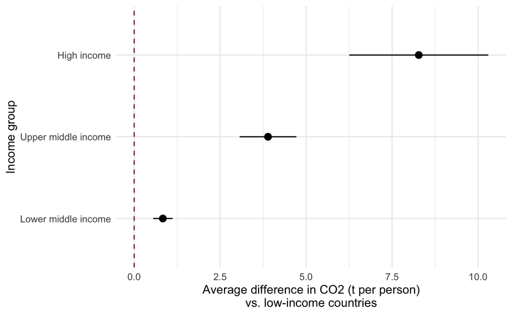

```r
plotdata <- lm_robust(co2 ~ income_level, data = Dat) %>%
  tidy() %>%
  mutate(term = str_remove(term, "income_level")) %>%
  filter(term != "(Intercept)")

ggplot(data = plotdata,
       aes(y = estimate, x = reorder(term, estimate))) +
  geom_hline(yintercept = 0, color = "#901A1E", lty = "dashed") +
  geom_pointrange(aes(ymin = conf.low, ymax = conf.high)) +
  coord_flip() +
  labs(x = "Income group",
       y = "Average difference in CO2 (t per person)\nvs. low-income countries") +
  theme_minimal()
```

The index runs from about −3 to +2, so build `fict_dat <- tibble(state_ownership = seq(-3, 2, by = 0.1))`, then `predict(ols_state, newdata = fict_dat, interval = "confidence")$fit`, turn it into a tibble and `bind_cols()` it back. Plot with `geom_ribbon()` + `geom_line()`.

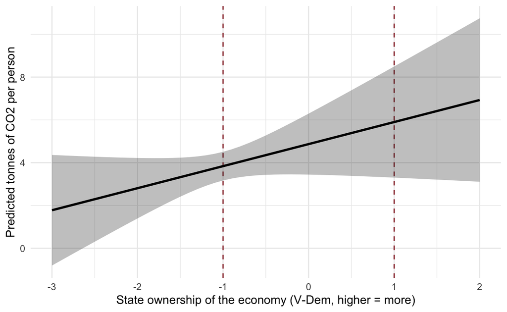

```r
ols_state <- lm_robust(co2 ~ state_ownership, data = Dat)

# Fictional countries spanning the observed range of the index
fict_dat <- tibble(state_ownership = seq(-3, 2, by = 0.1)) #<<
fict_dat <- predict(ols_state, newdata = fict_dat,
                    interval = "confidence", level = 0.95)$fit %>%
  as_tibble() %>%
  bind_cols(fict_dat, .)

ggplot(data = fict_dat, aes(y = fit, x = state_ownership)) +
  geom_vline(xintercept = c(-1, 1), color = "#901A1E", lty = "dashed") + #<<
  geom_ribbon(aes(ymin = lwr, ymax = upr), alpha = 0.3) +
  geom_line(linewidth = 1) +
  labs(x = "State ownership of the economy (V-Dem, higher = more)",
       y = "Predicted tonnes of CO2 per person") +
  theme_minimal()
```

5. **A prediction does not have to be a plot.** You can also ask the model for a *single number*. Using the **bivariate** model `co2 ~ state_ownership` from Exercise 1, predict CO₂ for a strongly market-based economy (`state_ownership = -1`, about where Denmark and Finland sit) and for a strongly state-run one (`state_ownership = +1`, about Russia and Angola). Build a `tibble()` with those two values and hand it to `predict()`.

```r
ols_state <- lm_robust(co2 ~ state_ownership, data = Dat)

fict_two <- tibble(state_ownership = c(-1, 1)) # market-based vs state-run #<<

predict(ols_state, newdata = fict_two,
        interval = "confidence", level = 0.95)$fit %>%
  as_tibble() %>%
  bind_cols(fict_two, .)
# # A tibble: 2 × 4
#   state_ownership   fit   lwr   upr
#             <dbl> <dbl> <dbl> <dbl>
# 1              -1  3.84  3.17  4.51
# 2               1  5.90  3.30  8.50
```

6. Look at the two **confidence intervals** you just produced. Which is wider, and why?

A prediction is only as good as the data behind it. Most countries in `Dat` sit on the market-based side, so the model has seen plenty of them and its interval there is narrow. Very few countries score high on state ownership, so out there the same model is guessing from a handful of cases — and says so, honestly, with a much wider interval. This is exactly the widening ribbon you drew in the prediction plot, read as numbers instead.

7. **Write one sentence** (as a `# comment`) that a reader of your term paper could follow, describing what the prediction plot shows. Then compare:

*Predicted CO₂ emissions rise with state ownership of the economy: a strongly market-based country is predicted to emit about 3.8 tonnes per person, a strongly state-run one about 5.9 — but the confidence ribbon fans out sharply on the right, where very few countries actually sit, so the model is far less sure about that end.*

8. **Discuss with your neighbour** — three steps toward the *carbon divide*:
   1. Your two figures tell the same story two ways. Which is clearer for a reader who has *never seen a regression table* — the coefficient plot or the prediction plot?
   2. The prediction plot looks clean and confident. But in Exercise 1 that same slope **reversed** once the petro economies were dropped. Could you honestly publish this figure on its own?
   3. The countries emitting the **least** are often the most exposed to climate damage. What does that mean for reading a "positive slope" as *good* or *bad* news?

**(a)** The prediction plot needs no statistics vocabulary — it reads like a line on a graph; the coefficient plot is compact but assumes the reader knows what a reference category is. **(b)** No. The figure is perfectly *correct* and still misleading on its own: it is drawn from a slope Exercise 1 showed is not robust, because the high-state-ownership end is populated by petro economies. A plot cannot show you what it excluded — which is why the robustness check belongs in the paper, not just in your script. **(c)** A positive slope is neither good nor bad by itself — it is the *injustice* that the low emitters bear the highest costs that turns the description into a research (and policy) agenda.

**Bonus (for the fast):** swap the coefficient plot's predictor from `income_level` to `region`. Which reference category does R pick, and how would you change it to `"Sub-Saharan Africa"`?

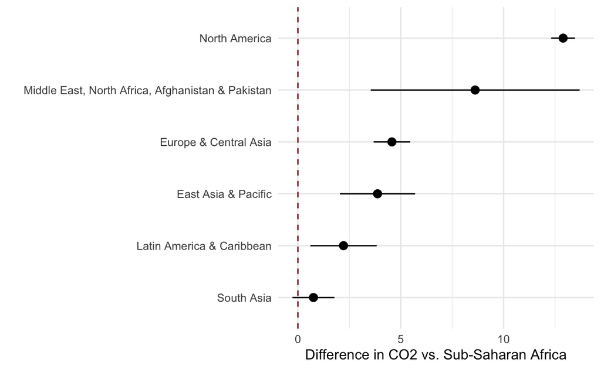

```r
# R uses the first factor level (alphabetical for a character vector) as the
# reference — so set it explicitly with fct_relevel(), as we did for income.
Dat <- Dat %>% mutate(region = fct_relevel(region, "Sub-Saharan Africa"))

lm_robust(co2 ~ region, data = Dat) %>%
  tidy() %>%
  mutate(term = str_remove(term, "region")) %>%
  filter(term != "(Intercept)") %>%
  ggplot(aes(y = estimate, x = reorder(term, estimate))) +
  geom_hline(yintercept = 0, color = "#901A1E", lty = "dashed") +
  geom_pointrange(aes(ymin = conf.low, ymax = conf.high)) +
  coord_flip() +
  labs(x = "", y = "Difference in CO2 vs. Sub-Saharan Africa") +
  theme_minimal()
```